# Metric MDS: SGD, SMACOF, and stress weighting

Installed figures use static projections. To enable 3D rotation and layout selection, render with `options(grip.vignette.interactive = TRUE)` and **ivue** and **rgl** installed.

`metric.mds()` fits Euclidean coordinates to graph shortest-path distances. The default `backend='sgd'` moves pairs of vertices in shuffled order, following [Zheng, Pawar and Goodman (2018)](https://doi.org/10.1109/TVCG.2018.2859997), with a selectable learning-rate schedule. Legacy graph calls default to the hybrid schedule adapted from the implementation of [Hangan, Kobourov and Miller (2026)](https://arxiv.org/abs/2605.00641); `prepare.sparse.mds()` inputs default to Zheng’s weight-dependent fixed-budget exponential schedule (`scheduler="zheng"`). `backend='smacof'` updates the full configuration using the optional [smacof package](https://doi.org/10.18637/jss.v102.i10). Its majorization steps are designed to reduce total stress; individual SGD pair adjustments need not.

This guide illustrates the differences using existing saved synthetic examples. For a broader comparison of the methods, see Hangan, Kobourov and Miller (2026). The complete experiment retains all 420 original fits, the separate 60-fit weighting comparison, failed outcomes, numerical results, and reproduction instructions.

For higher-dimensional fitting followed by PCA and optional free 3D refinement, see Higher-dimensional metric MDS for 3D visualization.

To record and animate actual SGD pair updates, see Animating metric MDS: paraboloid and saddle.

## Fit a graph with either backend

```r
g <- suitesparse.graph('dwt_307')
sgd <- metric.mds(edges=g$edges,n=g$n,dim=3,seed=1,
                  init='random',max.iter=100,diagnostics=FALSE)
smacof.fit <- metric.mds(edges=g$edges,n=g$n,dim=3,seed=1,
                  init='random',max.iter=100,diagnostics=FALSE,
                  backend='smacof',eps=1e-8)
```

This is a usage recipe, not a new benchmark on dwt_307. Both backends support uniform and inverse-squared stress weights. The default full mode uses uniform weights. An SGD pass and a SMACOF iteration are different amounts of work; compare achieved error and elapsed time, not iteration counts alone. SGD’s schedule completion reports `iteration_limit`, which does not certify convergence. The hybrid tuning defaults remain provisional calibration choices. The saved backend comparisons do not isolate the learning-rate schedule and therefore do not establish that hybrid is better than `"zheng"`. Hangan et al.’s fixed-switch rationale concerns the usual uniform-weight MDS setting; it is not evidence of superiority for inverse-squared regional sparse stress. See `?metric.mds`, under “Learning-rate schedules and evidence,” for the provenance, precise defaults and published-schedule controls.

## Two distance targets on the same saddle

The saved experiment uses 64- and 144-point clouds, five paired random starts, and separate allowances of 10, 30, or 100 passes/iterations. Both methods receive the same starting coordinates within each pair. Here we show the 144-point saddle at seed 1 and allowance 100, with uniform stress weights. These displayed runs were selected in advance, not chosen for their appearance.

**Ambient distances** are straight-line distances between generating points; an exact 3D realization exists. **Local graph paths** sum edge lengths along a finite grid with horizontal, vertical, and diagonal edges. They are not exact geodesics on the continuous saddle, and their best 3D drawing need not reproduce the generating surface.

### Ambient Euclidean

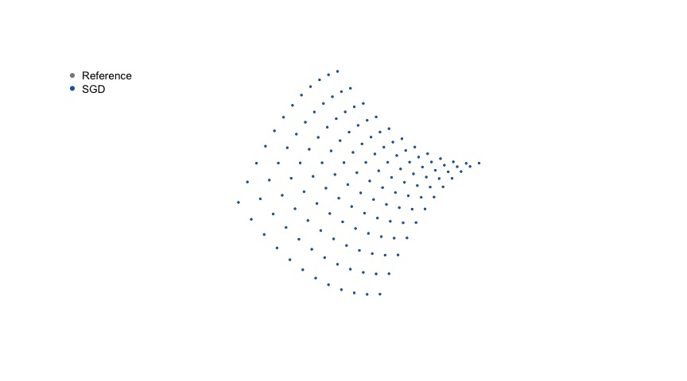

[output not shown]

### Local graph paths

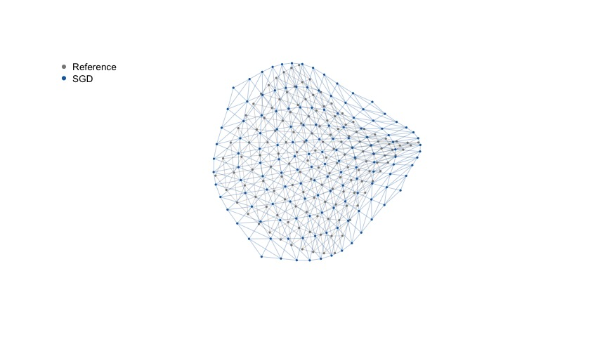

[output not shown]

Gray shows the generating reference; blue is SGD and orange is SMACOF. The ambient case uses matched-vertex alignment. The local-graph case uses surface-shape alignment: translation, rotation, and reflection match nearby surface locations without requiring vertex labels to agree. Neither alignment resizes or deforms the layouts. Scores use the original returned coordinates.

**Normalized error** is the square root of raw stress divided by the sum of squared target distances; lower is better. The figures below summarize both cloud sizes across five starts, with median errors and fitting times and interquartile ranges. Each point is a separate fit restarted with its own iteration allowance, not a checkpoint along one run. Fitting times exclude shared graph preparation, alignment, and rendering.

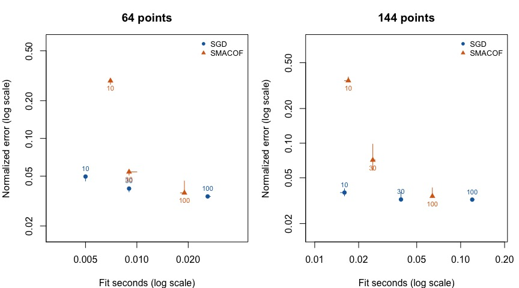

## The effect of stress weighting

Uniform weighting minimizes squared errors in distance units. The paper’s inverse-squared weighting minimizes squared **relative** distance errors:

$$\sum_{i<j} \frac{(\lVert z_i-z_j\rVert-d_{ij})^2}{d_{ij}^2}.$$

An error of 0.2 on a target distance of 1 then counts as much as an error of 2 on a target of 10. Edge lengths determine the target distances; `pair.weights` determines their influence on the objective.

```r
fit <- metric.mds(edges=g$edges,n=g$n,dim=3,
  pair.weights='inverse_squared',backend='sgd',seed=1)
```

The following comparison uses the saved 64-vertex saddle graph, seed 1, and allowance 100 for each backend and weighting. All four layouts use surface-shape alignment without resizing. Select a method and weighting below the figure, or show all four.

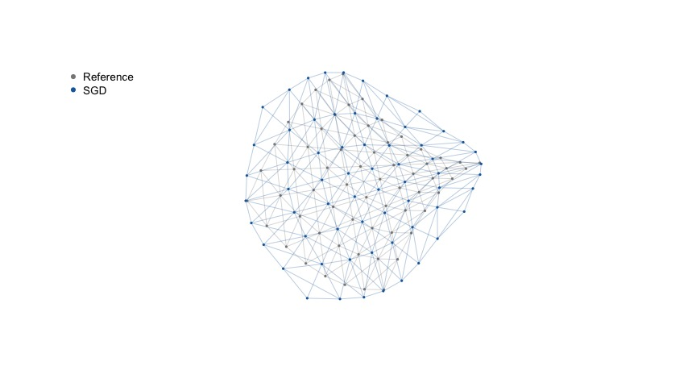

|  | backend | pair_weights | uniform_error | relative_error | seconds |
| --- | --- | --- | --- | --- | --- |
| sgd_uniform | sgd | uniform | 0.0344 | 0.0435 | 0.027 |
| sgd_inverse_squared | sgd | inverse_squared | 0.0382 | 0.0401 | 0.027 |
| smacof_uniform | smacof | uniform | 0.0462 | 0.0536 | 0.018 |
| smacof_inverse_squared | smacof | inverse_squared | 0.0385 | 0.0403 | 0.018 |

Compare errors within the same column: uniform and relative error express different priorities. The complete results include the five-start summaries, paraboloid and helix examples, and the surface-registration checks. For larger graphs, continue to Sparse SGD.